# 第五章 离散时间傅里叶变换

马越

北京理工大学机械与车辆学院  
Email: yuema@bit.edu.cn

## 离散时间傅里叶变换

设 $x$ 是一个非周期离散时间信号，并且 $\operatorname{supp} x \subset\left[N_{1}, N_{2}\right]$

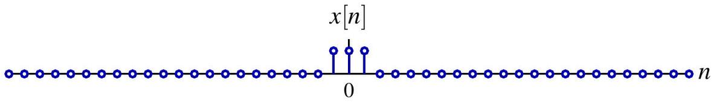

定义其周期延拓，周期满足 $N>N_{2}-N_{1}+1$：

$$x_{N}[n]=\sum_{k=-\infty}^{\infty} x[n+k N]$$

$$x_{N}[n]$$

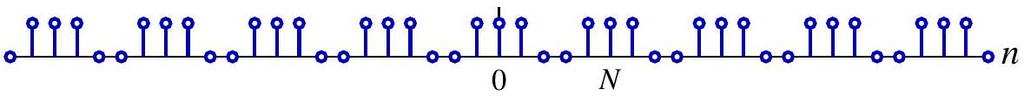

$x$ 可以看作“周期为无穷大”的周期信号，即 $x[n]=\lim _{N \rightarrow \infty} x_{N}[n]$

## 离散时间傅里叶变换

将 $x_{N}$ 展开为离散时间傅里叶级数

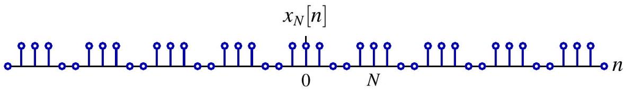

$$\hat{x}_{N}[k]=\left\langle x_{N}, e^{j k \frac{2 \pi}{N} n}\right\rangle=\frac{1}{N} \sum_{n=N_{1}}^{N_{2}} x[n] e^{-j k \frac{2 \pi}{N} n}=\frac{1}{N} X\left(e^{j k \omega_{0}}\right)$$

为了简化表达，我们取记号：

$$X\left(e^{j \omega}\right)=\sum_{n=N_{1}}^{N_{2}} x[n] e^{-j \omega n}=\sum_{n=-\infty}^{\infty} x[n] e^{-j \omega n}, \quad \omega_{0}=\frac{2 \pi}{N}$$
需要注意的是，$X\left(e^{j \omega}\right)$中的$\omega$是连续变量，$X\left(e^{j k \omega_{0} }\right)$是在离散点$k\omega_{0}$处的值。

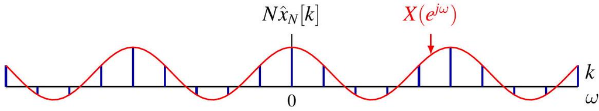

## 离散时间傅里叶变换

当 $N$ 增大时，离散频率的采样会变得更加稠密

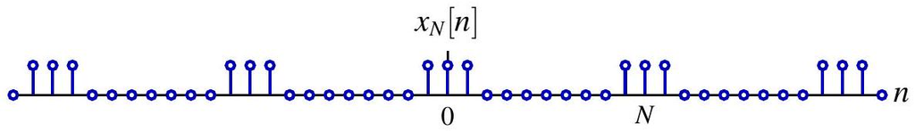

$$\hat{x}_{N}[k]=\left\langle x_{N}, e^{j k \frac{2 \pi}{N} n}\right\rangle=\frac{1}{N} \sum_{n=N_{1}}^{N_{2}} x[n] e^{-j k \frac{2 \pi}{N} n}=\frac{1}{N} X\left(e^{j k \omega_{0} }\right)$$

其中
$$X\left(e^{j \omega}\right)=\sum_{n=N_{1}}^{N_{2}} x[n] e^{-j \omega n}=\sum_{n=-\infty}^{\infty} x[n] e^{-j \omega n}, \quad \omega_{0}=\frac{2 \pi}{N}$$

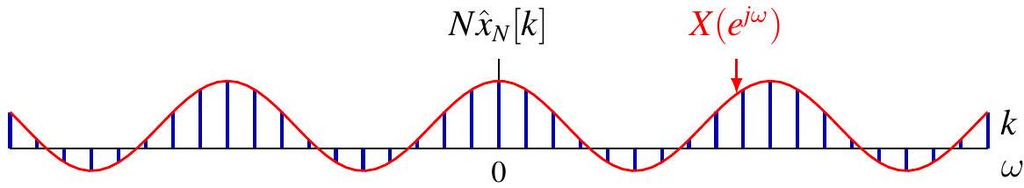

## 离散时间傅里叶变换

当 $N \rightarrow \infty$ 时，$N \hat{x}[k]$ 逐渐逼近包络 $X\left(e^{j \omega}\right)$

$$x_{N}[n]$$

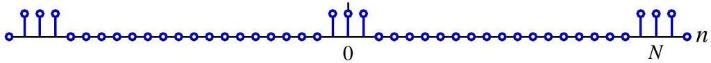

$$\hat{x}_{N}[k]=\left\langle x_{N}, e^{jk \frac{2 \pi}{N} n}\right\rangle=\frac{1}{N} \sum_{n=N_{1}}^{N_{2}} x[n] e^{-jk \frac{2 \pi}{N} n}=\frac{1}{N} X\left(e^{j k \omega_{0} }\right)$$

其中

$$X\left(e^{j \omega}\right)=\sum_{n=N_{1}}^{N_{2}} x[n] e^{-j \omega n}=\sum_{n=-\infty}^{\infty} x[n] e^{-j \omega n}, \quad \omega_{0}=\frac{2 \pi}{N}$$

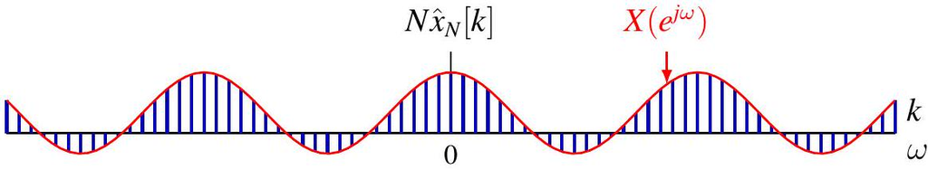

## 离散时间傅里叶变换

离散时间傅里叶级数的综合公式为：

$$x_{N}[n]=\sum_{k \in[N]} \hat{x}[k] e^{j k \omega_{0} n}=\frac{1}{N} \sum_{k=0}^{N-1} X\left(e^{j k \omega_{0}}\right) e^{j k \omega_{0} n}$$

令 $\omega_{k}=k \omega_{0}, \Delta \omega=\omega_{k}-\omega_{k-1}=\omega_{0}$，

$$x_{N}[n]=\frac{1}{2 \pi} \sum_{k=0}^{N-1} X\left(e^{j \omega_{k}}\right) e^{j \omega_{k} n} \Delta \omega$$

当 $N \rightarrow \infty$、$\Delta \omega \rightarrow 0$ 时，上述黎曼和变为积分：

$$x[n]=\frac{1}{2 \pi} \int_{0}^{2 \pi} X\left(e^{j \omega}\right) e^{j \omega n} d \omega=\frac{1}{2 \pi} \int_{2 \pi} X\left(e^{j \omega}\right) e^{j \omega n} d \omega$$

可在任意长度为 $2 \pi$ 的周期区间上积分

## 离散时间傅里叶变换变换对

离散时间傅里叶变换（分析公式）

$$X\left(e^{j \omega}\right)=\mathcal{F}(x)\left(e^{j \omega}\right)=\sum_{n=-\infty}^{\infty} x[n] e^{-j \omega n}$$

- $X\left(e^{j \omega}\right)$ 称为 $x[n]$ 的频谱，且以 $2 \pi$ 为周期

离散时间逆傅里叶变换（综合公式）

$$x[n]=\mathcal{F}^{-1}(X)[n]=\frac{1}{2 \pi} \int_{2 \pi} X\left(e^{j \omega}\right) e^{j \omega n} d \omega$$

- 频率为 $\omega$ 的复指数分量的权重为 $X\left(e^{j \omega}\right) \frac{d \omega}{2 \pi}$
- 只需在一个周期内积分，即只使用彼此不同的 $e^{j \omega n}$

## DTFT 与 CTFS 之间的对偶性

DTFT 变换对

- 离散时间
- 连续频率

分析公式

$$X\left(e^{j \omega}\right)=\sum_{n=-\infty}^{\infty} x[n] e^{-j \omega n}$$

综合公式

$$x[n]=\frac{1}{2 \pi} \int_{2 \pi} X\left(e^{j \omega}\right) e^{j \omega n} d \omega$$

CTFS 变换对

- 连续时间
- 离散频率

分析公式

$$\hat{x}[k]=\frac{1}{T} \int_{T} x(t) e^{-j k \frac{2 \pi}{T} t} d t$$

综合公式

$$x(t)=\sum_{k=-\infty}^{\infty} \hat{x}[k] e^{j k \frac{2 \pi}{T} t}$$

## 离散时间信号的高频与低频

$N$ 周期信号的离散频率

- 在单位圆上均匀分布的点
- 低频靠近 $1$；高频靠近 $-1$

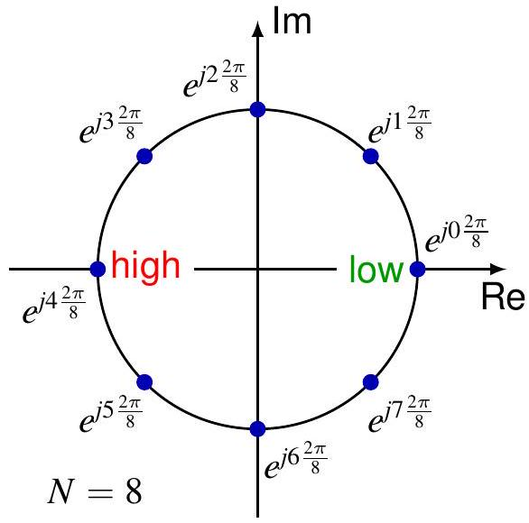

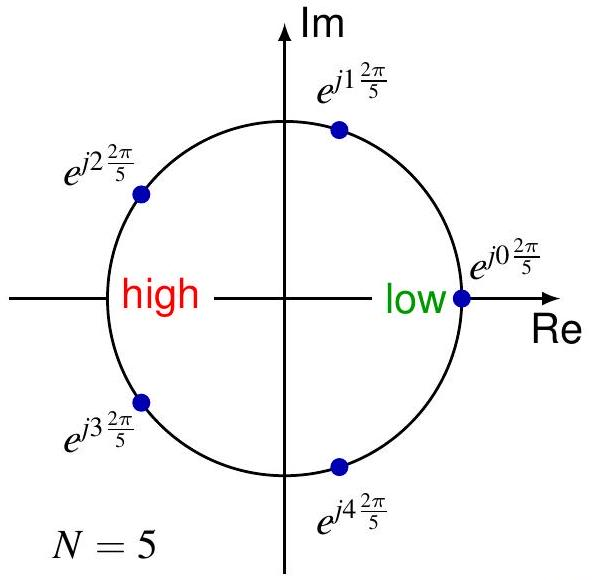

## 离散时间信号的高频与低频

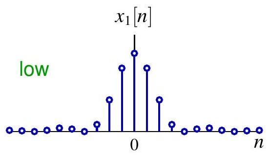

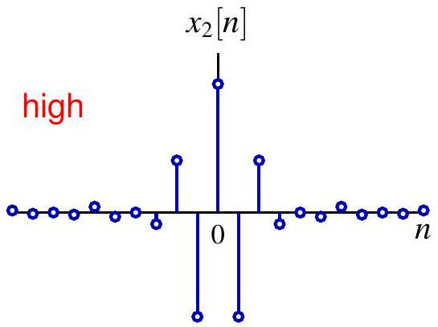

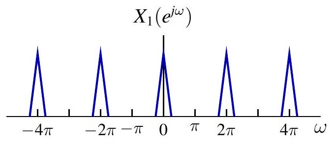

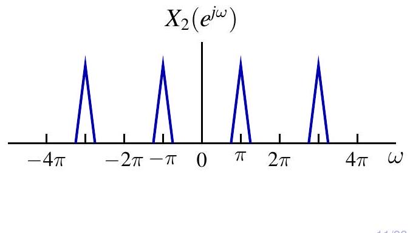

## 例：单边衰减指数序列

$$x[n]=a^{n} u[n] \stackrel{\mathcal{F}}{\longleftrightarrow} X\left(e^{j \omega}\right)=\frac{1}{1-a e^{-j \omega}}, \quad|a|<1$$

$\left|X\left(e^{j \omega}\right)\right|=\frac{1}{\sqrt{1-2 a \cos \omega+a^{2}}}, \quad \arg X\left(e^{j \omega}\right)=-\arctan \frac{a \sin \omega}{1-a \cos \omega}$

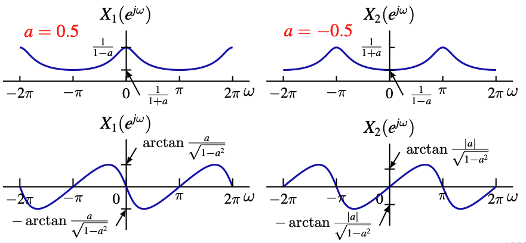

## 例：双边衰减指数序列

$$x[n]=a^{|n|} \stackrel{\mathcal{F}}{\longleftrightarrow} X\left(e^{j \omega}\right)=\frac{1-a^{2}}{1-2 a \cos \omega+a^{2}}, \quad|a|<1$$

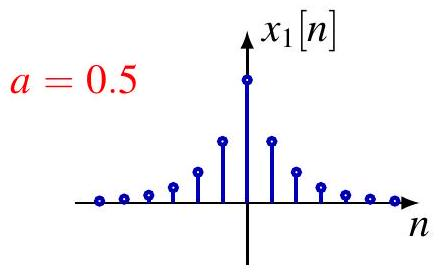

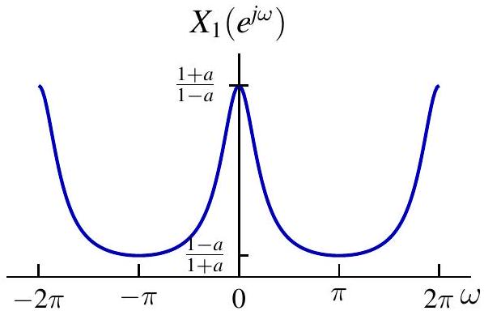

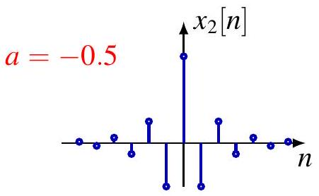

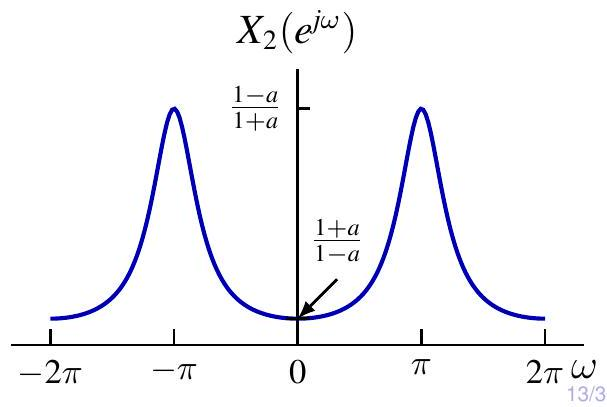

## 例：矩形脉冲

$$x[n]=u\left[n+N_{1}\right]-u\left[n-N_{1}-1\right] \stackrel{\mathcal{F}}{\longleftrightarrow} X\left(e^{j \omega}\right)=\frac{\sin \left(\frac{2 N_{1}+1}{2} \omega\right)}{\sin \frac{\omega}{2}}$$

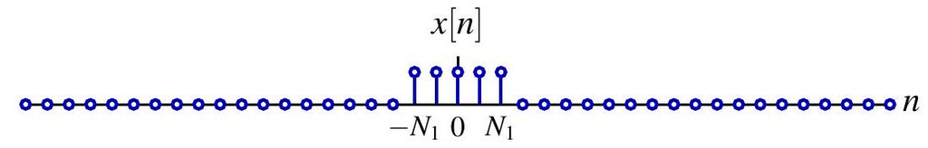

$$X\left(e^{j \omega}\right)$$

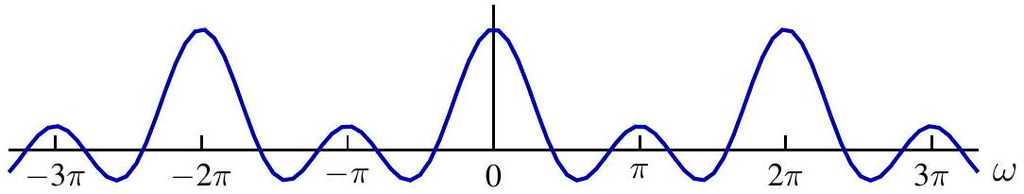

Dirichlet 核（周期情形）是 sinc 函数（非周期情形）在离散时间中的对应变换 注意：$N_{1}=0 \Longrightarrow x[n]=\delta[n] \stackrel{\mathcal{F}}{\longleftrightarrow} X\left(e^{j \omega}\right)=1$

## DTFT 的收敛性

令

$$X_{N}\left(e^{j \omega}\right)=\sum_{n=-N}^{N} x[n] e^{-j \omega n}$$

定理：若 $x \in \ell_{1}$，则 $X_{N}$ 一致收敛到 $X$，即

$$\lim _{N \rightarrow \infty}\left\|X-X_{N}\right\|_{\infty}=0$$

因此，傅里叶变换 $X$ 是一致连续的。

定理：若 $x \in \ell_{2}$，则 $X_{N}$ 在 $L_{2}$ 意义下收敛到 $X$，即

$$\lim _{N \rightarrow \infty}\left\|X-X_{N}\right\|_{2}=0$$

## 例：理想低通滤波器

$$\begin{aligned}
& x[n]=\frac{\sin (W n)}{\pi n} \stackrel{\mathcal{F}}{\longleftrightarrow} X\left(e^{j \omega}\right)=\sum_{k=-\infty}^{\infty}[u(\omega+W+2 k \pi)-u(\omega-W+2 k \pi)] \\
\end{aligned}$$

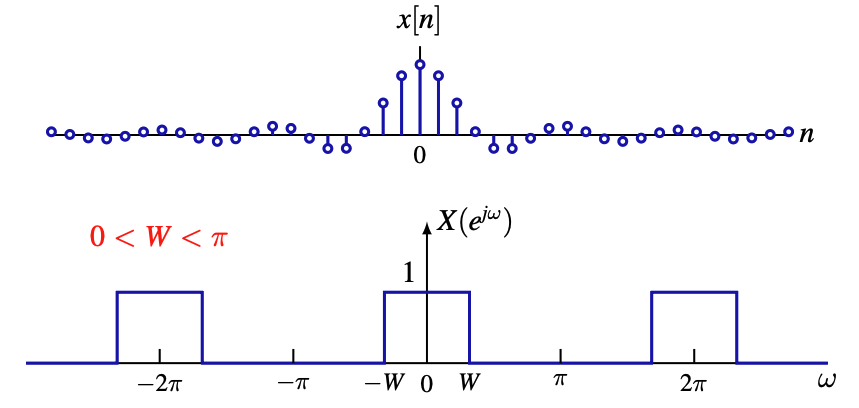

注意：$x \notin \ell_{1}$，且 $X$ 不连续

## 作为广义函数的收敛

复指数信号 $x[n]=e^{j \omega_{0} n}$ 不属于 $\ell_{1}$ 也不属于 $\ell_{2}$。

（平移后的）Dirichlet 核

$$X_{N}\left(e^{j \omega n}\right)=\frac{\sin \left(\frac{2 N_{1}+1}{2}\left(\omega-\omega_{0}\right)\right)}{\sin \frac{\omega-\omega_{0}}{2}} \rightarrow 2 \pi \sum_{\ell=-\infty}^{\infty} \delta\left(\omega-\omega_{0}-2 \ell \pi\right)$$

在分布（广义函数）意义下，有

$$x[n]=e^{j \omega_{0} n} \stackrel{\mathcal{F}}{\longleftrightarrow} X\left(e^{j \omega}\right)=2 \pi \sum_{\ell=-\infty}^{\infty} \delta\left(\omega-\omega_{0}-2 \ell \pi\right)$$

利用综合公式进行形式验证

$$x[n]=\frac{1}{2 \pi} \int_{-\pi}^{\pi} X\left(e^{j \omega}\right) e^{j \omega n} d \omega=\int_{-\pi}^{\pi} \delta\left(\omega-\omega_{0}\right) e^{j \omega n} d \omega=e^{j \omega_{0} n}$$

注意：也可通过对 $e^{j \omega_{0} t}$ 以 $T=1, \omega_{s}=2 \pi$ 采样得到

注意：$x[n]$ 不一定是周期信号！直流分量对应 $\omega_{0}=0$。

## 例：余弦信号

$$\begin{aligned}
x[n] & =\cos \left(\omega_{0} n+\phi\right)=\frac{e^{j \phi}}{2} e^{j \omega_{0} n}+\frac{e^{-j \phi}}{2} e^{-j \omega_{0} n} \\
X\left(e^{j \omega}\right) & =\sum_{\ell=-\infty}^{\infty} \pi e^{j \phi} \delta\left(\omega-\omega_{0}-2 \ell \pi\right)+\pi e^{-j \phi} \delta\left(\omega+\omega_{0}-2 \ell \pi\right)
\end{aligned}$$

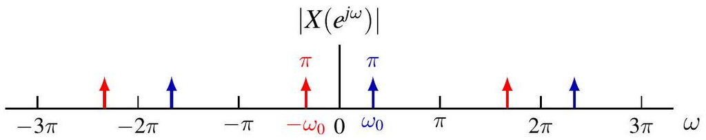

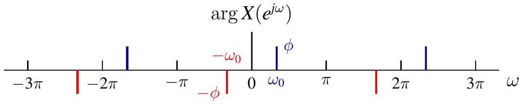

## 周期信号的 DTFT

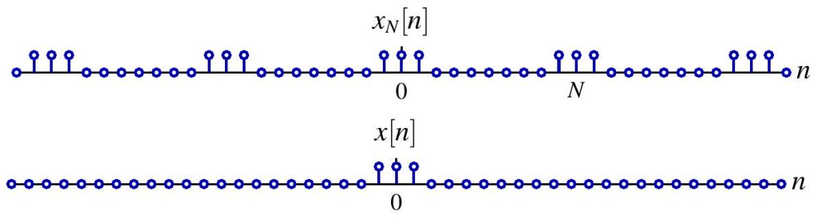

回顾：DTFS 系数 $\hat{x}_{N}[k]$ 就是频率 $k \omega_{0}$ 处的幅值

$$\hat{x}_{N}[k]=\frac{1}{N} X\left(e^{j k \omega_{0}}\right), \quad \text { 其中 } X=\mathcal{F}\{x\}, \quad \omega_{0}=\frac{2 \pi}{N}$$

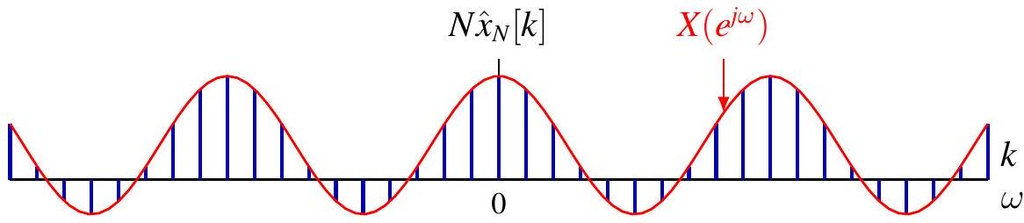

## 周期信号的 DTFT

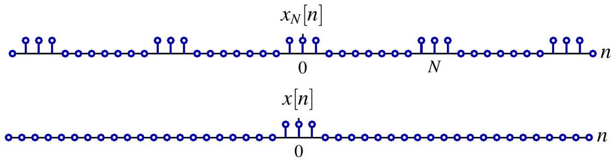

DTFT 中 $(2 \pi)^{-1} X\left(e^{j \omega}\right)$ 表示频率 $\omega$ 处的密度

$$X\left(e^{j \omega}\right)=2 \pi \sum_{k=-\infty}^{\infty} \hat{x}_{N}[k] \delta\left(\omega-k \omega_{0}\right)=\omega_{0} \sum_{k=-\infty}^{\infty} X\left(e^{j k \omega_{0}}\right) \delta\left(\omega-k \omega_{0}\right)$$

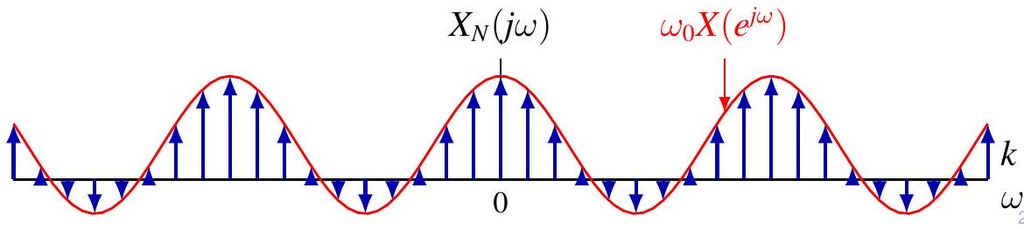

## 周期信号的 DTFT

回顾 $x_{N}$ 的 DTFS 表达式

$$x_{N}[n]=\sum_{k=0}^{N-1} \hat{x}_{N}[k] e^{j \frac{2 k \pi}{N} n}$$

对两边取 DTFT，并利用线性性质以及复指数信号的 DTFT，得到

$$\begin{aligned}
X_{N}\left(e^{j \omega}\right) & =\sum_{k=0}^{N-1} \hat{x}_{N}[k] \mathcal{F}\left\{e^{j \frac{2 k \pi}{N} n}\right\}=\sum_{k=0}^{N-1} \hat{x}_{N}[k] \sum_{\ell=-\infty}^{\infty} 2 \pi \delta\left(\omega-\frac{2 k \pi}{N}-2 \ell \pi\right) \\
& =2 \pi \sum_{\ell=-\infty}^{\infty} \sum_{k=0}^{N-1} \hat{x}_{N}[k] \delta\left(\omega-\frac{2(k+\ell N) \pi}{N}\right) \\
& =2 \pi \sum_{k=-\infty}^{\infty} \hat{x}_{N}[k] \delta\left(\omega-\frac{2 k \pi}{N}\right) \quad\left(\text { 根据 } \hat{x}_{N}[k]=\hat{x}_{N}[k+\ell N]\right)
\end{aligned}$$

## 周期信号的 DTFT

也可以使用综合公式（即逆变换公式）进行正式验证

$$\frac{1}{2 \pi} \int_{-\frac{\pi}{N}}^{2 \pi-\frac{\pi}{N}} X\left(e^{j \omega}\right) e^{j \omega n} d \omega=\int_{-\frac{\pi}{N}}^{2 \pi-\frac{\pi}{N}} \sum_{k=-\infty}^{\infty} \hat{x}_{N}[k] \delta\left(\omega-\frac{2 k \pi}{N}\right) e^{j \omega n} d \omega$$

只有 $k=0,1, \ldots, N-1$ 的项落在积分区间内

$$\int_{-\frac{\pi}{N}}^{2 \pi-\frac{\pi}{N}} \sum_{k=0}^{N-1} \hat{x}_{N}[k] \delta\left(\omega-\frac{2 k \pi}{N}\right) e^{j \omega n} d \omega=\sum_{k=0}^{N-1} \hat{x}_{N}[k] e^{j \frac{2 k \pi}{N} n}=x_{N}[n]$$

最后一个等号实际上就是离散时间傅里叶级数（DTFS）的综合公式，因此下面的DTFT综合公式得到验证。

$$x_{N}[n]=\frac{1}{2 \pi} \int_{2 \pi} X\left(e^{j \omega}\right) e^{j \omega n} d \omega$$

## 例：离散时间周期冲激串

$$x[n]=\sum_{k=-\infty}^{\infty} \delta[n-k N] \stackrel{\mathcal{F}}{\longleftrightarrow} X\left(e^{j \omega}\right)=\frac{2 \pi}{N} \sum_{k=-\infty}^{\infty} \delta\left(\omega-\frac{2 \pi k}{N}\right)$$

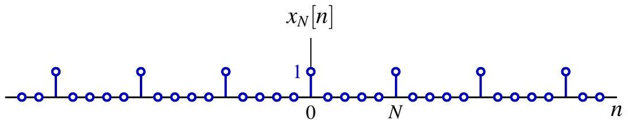

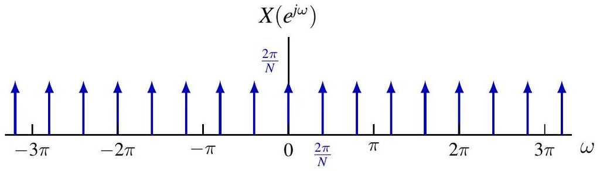

## 目录

- 1. 非周期信号的表示：离散时间傅里叶变换
- **2. 离散时间傅里叶变换的性质**
- 3. 卷积性质
- 4. 乘积性质
- 5. 变换性质和变换对列表
- 6. 对偶性
- 7. 由线性常系数差分方程表征的系统

## 离散时间傅里叶变换的性质

**周期性**

$$X\left(e^{j(\omega+2 \pi)}\right)=X\left(e^{j(\omega)}\right)$$

**线性**

$$\mathcal{F}\{a x+b y\}=a \mathcal{F}\{x\}+b \mathcal{F}\{y\}$$

**时移与频移**

若

$$x[n] \stackrel{\mathcal{F}}{\longleftrightarrow} X\left(e^{j \omega}\right)$$

则

$$x\left[n-n_{0}\right] \stackrel{\mathcal{F}}{\longleftrightarrow} e^{-j \omega n_{0}} X\left(e^{j \omega}\right)$$

并且

$$e^{j \omega_{0} n} x[n] \stackrel{\mathcal{F}}{\longleftrightarrow} X\left(e^{j\left(\omega-\omega_{0}\right)}\right)$$

## 例：高通与低通滤波器

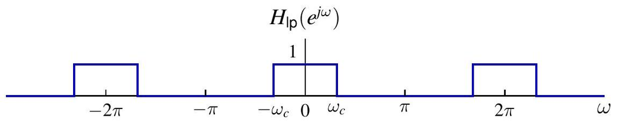

$$H_{\mathrm{hp}}\left(e^{j \omega}\right)=H_{\mathrm{lp}}\left(e^{j(\omega-\pi)}\right)$$

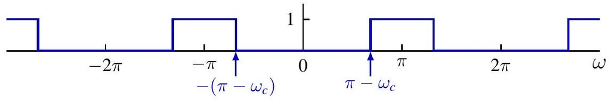

$$H_{\mathrm{hp}}\left(e^{j \omega}\right)=H_{\mathrm{lp}}\left(e^{j(\omega-\pi)}\right) \Longleftrightarrow h_{\mathrm{hp}}[n]=e^{j \pi n} h_{\mathrm{lp}}[n]=(-1)^{n} h_{\mathrm{lp}}[n]$$

利用低通滤波器实现高通滤波 $y=x * h_{\mathrm{hp}}$

1. $x_{1}[n]=(-1)^{n} x[n]$；
2. $y_{1}=x_{1} * h_{\mathrm{lp}}$；
3. $y[n]=(-1)^{n} y_{1}[n]$

## 离散时间傅里叶变换的性质

设

$$x[n] \stackrel{\mathcal{F}}{\longleftrightarrow} X\left(e^{j \omega}\right)$$

时间反转

$$x[-n] \stackrel{\mathcal{F}}{\longleftrightarrow} X\left(e^{-j \omega}\right)$$

共轭

$$x^{*}[n] \stackrel{\mathcal{F}}{\longleftrightarrow} X^{*}\left(e^{-j \omega}\right)$$

对称性

- $x$ 为偶信号 $\Longleftrightarrow X$ 为偶函数，$\quad x$ 为奇信号 $\Longleftrightarrow X$ 为奇函数
- $x$ 为实信号 $\Longleftrightarrow X\left(e^{-j \omega}\right)=X^{*}\left(e^{j \omega}\right)$
- $x$ 为实信号 并且 是 偶函数 $\Longleftrightarrow X$ 是实信号 并且 是偶函数
- $x$ 为实信号 并且 是奇函数 $\Longleftrightarrow X$ 纯虚信号 并且 是奇函数